# tentative report

Motivation: Provide an overview of the project goals and motivation.

Related work: Anything that inspired you, such as a paper, a web site, or something we discussed in class.

Initial questions: What questions are you trying to answer? How did these questions evolve over the course of the project? What new questions did you consider in the course of your analysis?

Data: Source, scraping method, cleaning, etc.

Exploratory analysis: Visualizations, summaries, and exploratory statistical analyses. Justify the steps you took, and show any major changes to your ideas.

Additional analysis: If you undertake formal statistical analyses, describe these in detail

Discussion: What were your findings? Are they what you expect? What insights into the data can you make?

### Motivation:

A major concern in emergency medical services (EMS) planning has been the need to minimize response time to better patient outcome, translated by some EMS operations into a goal of a response time of 8 minutes or less for advanced life support (ALS) units responding to life-threatening events. An exploratory analysis suggested there may be a small beneficial effect of response ≤7 minutes 59 seconds for those who survived to become an inpatient. More information on this can be found [here](https://www.ncbi.nlm.nih.gov/pubmed/11927452) and [here](https://www.ncbi.nlm.nih.gov/pubmed/22026820)

Due to its large population, New York City requires a powerful, quick, well-equipped and effective Emergency Medical Service System. Hence, we decided to analyse the EMS response time in New York City in the year 2017 with respect to weather and street blockage so as to improve it.

### Initial questions:

We tried to answer the factors assoicated with EMS response time. We assumed rainy or snowy conditions, season and hour of the day will affect the response time.

Some of the questions that drove our analysis were:

- How does season, hour of the day, rainy or snowly conditions affect the response time?
- What other factors affect response time?

[This](https://www.ncbi.nlm.nih.gov/pubmed/29381111) study done in California county early this year challenges the commonly held assumption that ambulances are later to poor neighborhoods. This got us interested in exploring the relationship in emergency response time between a economically well off area - Upper West Side and a relatively poorer area such as Washington Heigths.

### Data Source

**The New York City Weather Data**

[This](https://www.ncdc.noaa.gov/cdo-web/datasets) dataset includes weather records of the city from 2014- 2018. We have restrcited our analysis to 2017 so the data was filtered accordingly. From this dataset, we have selected precipication, snow, snow depth and maximum and minimum temperatures everyday throughout the year.

Street Closure due to Construction data : [This](https://data.cityofnewyork.us/Transportation/Street-Closures-due-to-construction-activities-by-/478a-yykk) For this project, we were interested in how street closures in NYC affects the response time. For this, we have acquired DOT Street Closure Data. DOT Street Closure data identifies locations in the New York City Street Closure map where a street is subject to a full closure, restricting through traffic, for the purpose of conducting construction related activity on a City street. From this datset of 7 columns, we have filtered out work state and end date in 2017, on and from street and borough code for our interest.

**Limitations of our analysis:** response time ‘clock’ almost universally stops when the unit arrives in front of the address; in large office or apartment buildings, actually accessing the patient may take several minutes longer, but this is not considered in response time calculation or reporting.

### Exploratory analysis:

### Step 1: Data preparation

1. Incident data (response from Fire company)

```r
incident_dat_2017 <-
  read_csv('data/Incidents_Responded_to_by_Fire_Companies.csv',
  col_types = "cicccicciccccccccccciccccccc") %>%
  janitor::clean_names() %>%
  #recode date/time
  mutate(incident_date_time = mdy_hms(incident_date_time),
         arrival_date_time = mdy_hms(arrival_date_time)) %>%
  #select year 2017
  filter(year(incident_date_time) == 2017,
         incident_type_desc == "300 - Rescue, EMS incident, other") %>%
  select(im_incident_key, incident_date_time, arrival_date_time,
         street_highway:borough_desc) %>%
  na.omit() %>%

  # Added response time(minute) variable
  # mutate(response_time = arrival_date_time - incident_date_time) %>%
  mutate(response_time = difftime(arrival_date_time, incident_date_time, units = 'mins'),
  # Added hour variable
  hour = hour(incident_date_time),
  date = date(incident_date_time),
  # Added incident_month and incident_day variables from incident_date_time
  incident_date = as.Date(incident_date_time)) %>%
  separate(incident_date,
           into = c("incident_year", "incident_month", "incident_day"),
           sep = "-") %>%
  select(-incident_year) %>%
  mutate(incident_month = as.numeric(incident_month),
         incident_day = as.numeric(incident_day),
         zip_code = as.numeric(zip_code))

save(incident_dat_2017, file = "data/incident_dat_2017.RData")
```

2. Neighborhood variable (by zipcode) dataset

```r
url = "https://www.health.ny.gov/statistics/cancer/registry/appendix/neighborhoods.htm?fbclid=IwAR3N4VlKC1OehRZyEuDYPEAE7AFAEXXIRC11seIBKxA-0fd3g4hL0QvnV20"

xml = read_html(url)

zip_code_table = (xml %>% html_nodes(css = "table")) %>%
  .[[1]] %>%
  html_table() %>%
  janitor::clean_names() %>%
  select(neighborhood, zip_codes) %>%
  separate(zip_codes, c("a", "b", "c", "d", "e", "f", "g", "h", "i"),
           sep = ",") %>%
  gather(key = to_remove, value = zip_code, a:i) %>%
  select(-to_remove) %>%
  na.omit() %>%
  distinct() %>%
  mutate(zip_code = as.numeric(zip_code))

save(zip_code_table, file = "data/zipcode.RData")
```

3. Add weather-related dataset

```r
library(rnoaa)

nyc_weather_2017 =
  rnoaa::meteo_pull_monitors("USW00094728",
                             var = c("PRCP", "TMIN", "TMAX", "SNOW", "SNWD"),
                             date_min = "2017-01-01",
                             date_max = "2017-12-31"
                             ) %>%
  mutate(tmin = tmin/10, tmax = tmax/10, prcp = prcp/10) %>%
  select(-id)

save(nyc_weather_2017, file = "data/nyc_weather_2017.RData")
```

4. Merge first three for final dataset

```r
# incident_dat_2017
finaldat =
  left_join(incident_dat_2017, zip_code_table, by = "zip_code") %>%
  inner_join(., nyc_weather_2017, by = "date") %>%
  mutate(response_time = as.numeric(response_time))

save(finaldat, file = "data/finaldat.RData")

load('data/finaldat.RData')
```

Given that data of response time is right skewed, for visulization, we took a mean of response time as our outcome for exploratory analysis And then performed exploratory data analysis.

### Step 2: Initial analysis (obsolete)

#### Step 2-1: EDA

1. Hourly trend of response time

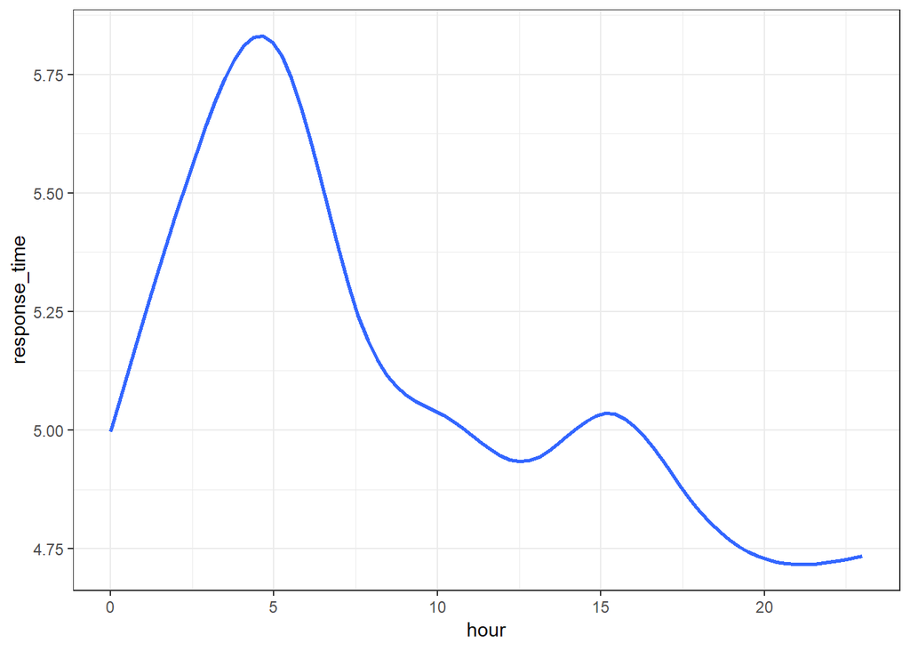

```r
finaldat %>%
  group_by(hour) %>%
  ggplot(aes(x = hour, y = response_time)) +
  geom_smooth(se = FALSE)
```

2. Response time in rainy and snowy days

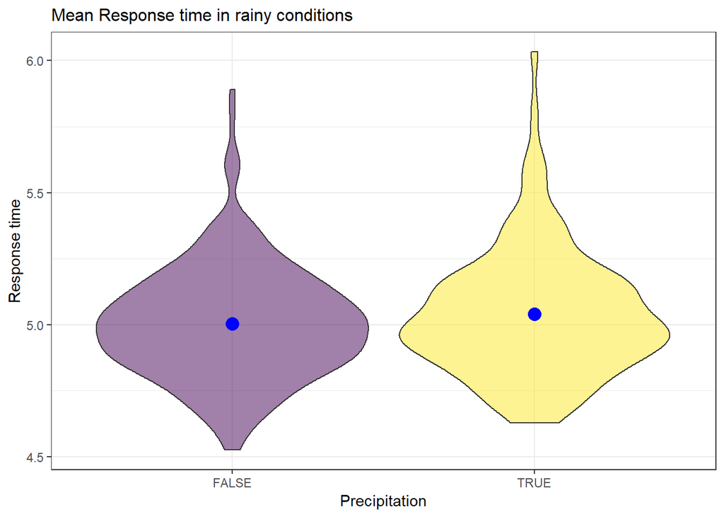

```r
finaldat %>%
  mutate(prcp = prcp > 0) %>%
  group_by(date, prcp) %>%
  summarise(mean_resp_time = mean(response_time)) %>%
  ggplot(aes(x = prcp, y = mean_resp_time)) +
  geom_violin(aes(fill = factor(prcp)), alpha = .5) +
  stat_summary(fun.y = mean, geom = "point", size = 4, color = "blue") +
  labs(
    title = "Mean Response time in rainy conditions",
    x = "Precipitation",
    y = "Response time"
  ) +
  viridis::scale_fill_viridis(
    name = "Precipitation",
    discrete = TRUE) +
  theme(plot.title = element_text(size = 12),
        strip.background = element_rect(fill = "black"),
        strip.text = element_text(color = "white", face = "bold"),
        legend.position = "None")
```

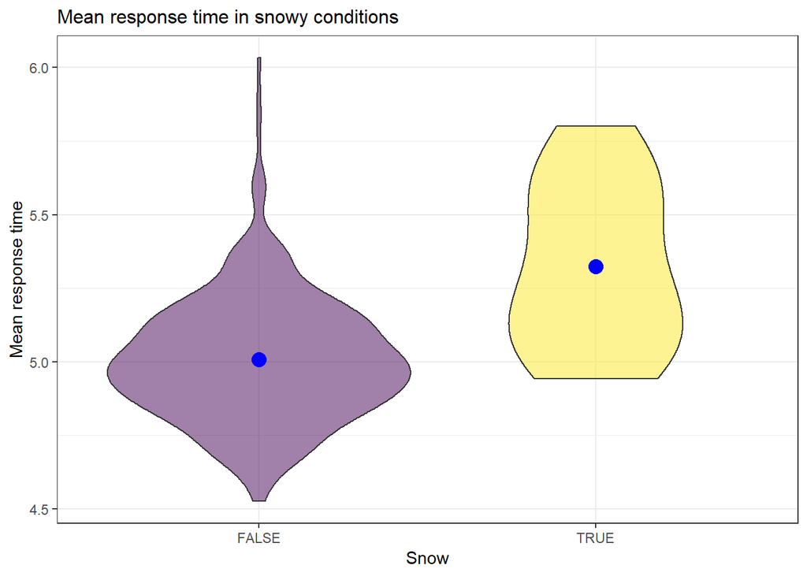

```r
finaldat %>%
  mutate(snow = snow > 0) %>%
  group_by(date, snow) %>%
  summarise(mean_resp_time = mean(response_time)) %>%
  ggplot(aes(x = snow, y = mean_resp_time)) +
  geom_violin(aes(fill = factor(snow)), alpha = .5) +
  stat_summary(fun.y = mean, geom = "point", size = 4, color = "blue") +
  labs(
    title = "Mean response time in snowy conditions",
    y = "Mean response time",
    x = "Snow"
  ) +
  viridis::scale_fill_viridis(
    name = "Snow",
    discrete = TRUE) +
  theme(plot.title = element_text(size = 12),
        strip.background = element_rect(fill = "black"),
        strip.text = element_text(color = "white", face = "bold"),
        legend.position = "None")
```

We showed some trends by hour of the day and by snowy conditions. Based on this result, we fit linear regression.

#### Step 2-2: Linear regression

1. hour of the day vs response time

```r
fit_hour = lm(response_time ~ hour, data = finaldat)
fit_hour %>%
  broom::tidy() %>%
  knitr::kable(digits = 3)
```

| term | estimate | std.error | statistic | p.value |
| --- | --- | --- | --- | --- |
| (Intercept) | 5.470 | 0.017 | 317.714 | 0 |
| hour | -0.034 | 0.001 | -29.176 | 0 |

2. snow & prcp vs response time —– linear regression

```r
fit_snow = lm(response_time~snow, data = finaldat)
fit_snow %>%
  broom::tidy() %>%
  knitr::kable(digits = 3)
```

| term | estimate | std.error | statistic | p.value |
| --- | --- | --- | --- | --- |
| (Intercept) | 5.009 | 0.007 | 678.552 | 0 |
| snow | 0.003 | 0.000 | 7.456 | 0 |

```r
fit_prcp = lm(response_time~prcp, data = finaldat)
fit_prcp %>%
  broom::tidy() %>%
  knitr::kable(digits = 3)
```

| term | estimate | std.error | statistic | p.value |
| --- | --- | --- | --- | --- |
| (Intercept) | 5.005 | 0.008 | 647.000 | 0 |
| prcp | 0.003 | 0.001 | 4.014 | 0 |

3. MLR based on snow, prcp, tmax, tmin(factors of nature environment) in different hour of the day

```r
fit_mlr = lm(response_time~snow + prcp + tmax + tmin, data = finaldat)

fit_mlr %>%
  broom::tidy() %>%
  knitr::kable(digits = 3)
```

| term | estimate | std.error | statistic | p.value |
| --- | --- | --- | --- | --- |
| (Intercept) | 5.077 | 0.022 | 226.683 | 0.000 |
| snow | 0.002 | 0.000 | 4.539 | 0.000 |
| prcp | 0.002 | 0.001 | 2.830 | 0.005 |
| tmax | 0.000 | 0.003 | 0.123 | 0.902 |
| tmin | -0.008 | 0.003 | -2.742 | 0.006 |

Even though we could get the statistically significant results with p-values less than 0.05, the estimates are too small so explanations from this was not meaningful.

### Step 3: final analysis

#### Step 3-1: Modify variables

Next, we categorized explanatory variables since we wanted to show the change of response time by the trend of precipitation, snow, season and time rather than by detailed amount of precipitation and snow or specific time. With these modified variables, we performed exploratory data analysis.

#### Step 3-2:EDA based on modified variables

1. precipitation and snow

```r
prcp_eda =
  finaldat %>%
  mutate(prcp_ctg = fct_relevel(prcp_ctg, c("no_prcp", "low", "high"))) %>%
  group_by(date, prcp_ctg) %>%
  summarise(mean_resp_time = mean(response_time)) %>%
  ggplot(aes(x = prcp_ctg, y = mean_resp_time)) +
  geom_violin(aes(fill = prcp_ctg), alpha = .3) +
  stat_summary(fun.y = mean, geom = "point", size = 2, color = "blue") +
  labs(
    title = "Rainy conditions",
    y = "Mean response time(min)",
    x = " "
  ) +
  scale_x_discrete(labels = c("0(mm)", "0-25(mm)", "25(mm)+")) +
  viridis::scale_fill_viridis(
    name = "Precipitation",
    discrete = TRUE) +
  theme(plot.title = element_text(size = 12),
        axis.title.y = element_text(size = 8),
        axis.text.x = element_text(size = 9),
        legend.position = "None")

snow_eda =
  finaldat %>%
  mutate(snow_ctg = fct_relevel(snow_ctg, c("no_snow", "low", "high"))) %>%   group_by(date, snow_ctg) %>%
  summarise(mean_resp_time = mean(response_time)) %>%
  ggplot(aes(x = snow_ctg, y = mean_resp_time)) +
  geom_violin(aes(fill = snow_ctg), alpha = .3) +
  stat_summary(fun.y = mean, geom = "point", size = 2, color = "blue") +
  labs(
    title = "Snowy conditions",
    y = "",
    x = " "
  ) +
  scale_x_discrete(labels = c("0(mm)", "0-50(mm)", "50(mm)+")) +
  viridis::scale_fill_viridis(
    name = "Snow",
    discrete = TRUE) +
  theme(plot.title = element_text(size = 12),
        axis.title.y = element_text(size = 9),
        axis.text.x = element_text(size = 8),
        legend.position = "None")

prcp_snow = prcp_eda + snow_eda
ggsave("prcp_snow.png", plot = prcp_snow)
```

2. Season

```r
season_eda =
finaldat %>%
  mutate(season = fct_relevel(season, c("Spring", "Summer", "Fall", "Winter"))) %>%
  group_by(date, season) %>%
  summarise(mean_resp_time = mean(response_time)) %>%
  ggplot(aes(x = season, y = mean_resp_time)) +
  geom_violin(aes(fill = season), alpha = .3) +
  stat_summary(fun.y = mean, geom = "point", size = 2, color = "blue") +
  labs(
    y = "Mean response time (min)",
    x = " "
  ) +
  viridis::scale_fill_viridis(
    name = "season",
    discrete = TRUE) +
  theme(plot.title = element_text(size = 13),
        axis.title.y = element_text(size = 10),
        axis.text.x = element_text(size = 9),
        legend.position = "None")

ggsave("season.png", plot = season_eda)
```

3. Hour

```r
hour_eda =
finaldat %>%
  group_by(hour, season) %>%
  ggplot(aes(x = hour, y = response_time, color = season)) +
  geom_smooth(se = FALSE) +
  scale_x_continuous(breaks = c(6, 12, 18),
                     labels = c("6am", "12pm", "18pm")) +
  geom_vline(xintercept = c(6, 12, 18), color = "darkred") +
  labs(
    x = " ",
    y = "Mean response time (min)"
    ) +
   viridis::scale_color_viridis(
    name = "Season",
    discrete = TRUE)
  theme(plot.title = element_text(size = 13),
        axis.title.y = element_text(size = 10),
        axis.text.x = element_text(size = 12),
        legend.position = "None")
```

[output not shown]

```r
ggsave("hour.png", plot = hour_eda)
```

Accordingly, based on medical research, using a fact that 8min is a critical point, we categorized response time into binary outcome as less than 8min and over 8min.

#### Step 3-3:Logistic regression

```r
finaldat =
  finaldat %>%
  mutate(prcp_ctg = fct_relevel(prcp_ctg, "no_prcp"),
         snow_ctg = fct_relevel(snow_ctg, "no_snow"),
         season = fct_relevel(season, "Spring"),
         hour_of_day = fct_relevel(hour_of_day, "night"))

fit_logistic =
  glm(over_8min ~ season + hour_of_day + snow_ctg + prcp_ctg,
      family = binomial(), data = finaldat)

summary(fit_logistic)
```

```
##
## Call:
## glm(formula = over_8min ~ season + hour_of_day + snow_ctg + prcp_ctg,
##     family = binomial(), data = finaldat)
##
## Deviance Residuals:
##     Min       1Q   Median       3Q      Max
## -0.4561  -0.3762  -0.3658  -0.3271   2.4710
##
## Coefficients:
##                       Estimate Std. Error  z value Pr(>|z|)
## (Intercept)          -2.959451   0.028609 -103.443  < 2e-16 ***
## seasonFall            0.058271   0.028900    2.016  0.04377 *
## seasonSummer         -0.002128   0.028837   -0.074  0.94117
## seasonWinter          0.070643   0.029485    2.396  0.01658 *
## hour_of_dayafternoon  0.300029   0.026713   11.231  < 2e-16 ***
## hour_of_daydawn       0.230470   0.034634    6.654 2.84e-11 ***
## hour_of_daymorning    0.314235   0.028550   11.006  < 2e-16 ***
## snow_ctghigh          0.387983   0.084315    4.602 4.19e-06 ***
## snow_ctglow           0.212878   0.077437    2.749  0.00598 **
## prcp_ctghigh         -0.042873   0.057984   -0.739  0.45967
## prcp_ctglow          -0.024086   0.023208   -1.038  0.29936
## ---
## Signif. codes:  0 '***' 0.001 '**' 0.01 '*' 0.05 '.' 0.1 ' ' 1
##
## (Dispersion parameter for binomial family taken to be 1)
##
##     Null deviance: 78187  on 167589  degrees of freedom
## Residual deviance: 77979  on 167579  degrees of freedom
## AIC: 78001
##
## Number of Fisher Scoring iterations: 5
```

```r
fit_logistic %>%
  broom::tidy() %>%
  mutate(OR = exp(estimate),
         lower_CI_OR = exp(estimate - 1.96*std.error),
         upper_CI_OR = exp(estimate + 1.96*std.error)) %>%
  select(term, OR, lower_CI_OR, upper_CI_OR) %>%
  mutate(term = c("intercept", "Fall", "Summer", "Winter", "Afternoon", "Dawn", "Morning", "snow 50+", "snow 50-", "prcp 25+", "prcp 25-")) %>%   knitr::kable(digits = 3, "html") %>% kableExtra::kable_styling(bootstrap_options = c("striped", "hover"))
```

| term | OR | lower_CI_OR | upper_CI_OR |
| --- | --- | --- | --- |
| intercept | 0.052 | 0.049 | 0.055 |
| Fall | 1.060 | 1.002 | 1.122 |
| Summer | 0.998 | 0.943 | 1.056 |
| Winter | 1.073 | 1.013 | 1.137 |
| Afternoon | 1.350 | 1.281 | 1.422 |
| Dawn | 1.259 | 1.177 | 1.348 |
| Morning | 1.369 | 1.295 | 1.448 |
| snow 50+ | 1.474 | 1.249 | 1.739 |
| snow 50- | 1.237 | 1.063 | 1.440 |
| prcp 25+ | 0.958 | 0.855 | 1.073 |
| prcp 25- | 0.976 | 0.933 | 1.022 |

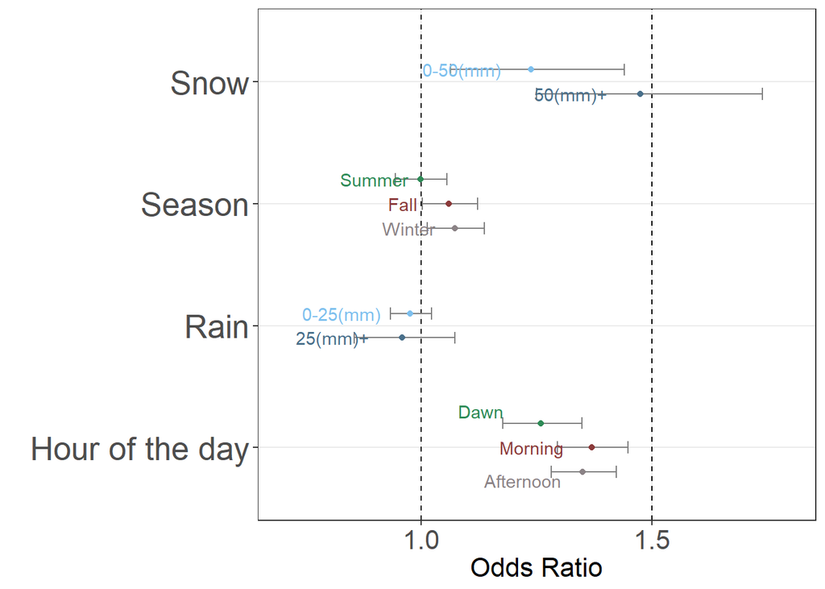

```r
OR_total_df =
fit_logistic %>%
  broom::tidy() %>%
  mutate(OR = exp(estimate),
         lower_CI_OR = exp(estimate - 1.96*std.error),
         upper_CI_OR = exp(estimate + 1.96*std.error)) %>%
  select(term, OR, lower_CI_OR, upper_CI_OR) %>%
  as.tibble() %>%
  mutate(ctg = c("intercept",
                 "Season", "Season", "Season",
                 "Hour of the day", "Hour of the day", "Hour of the day",
                 "Snow", "Snow",
                 "Rain", "Rain"),
         sub_ctg_chr = c("intercept",
                     "Fall", "Summer", "Winter",
                     "Afternoon", "Dawn", "Morning",
                     "50(mm)+", "0-50(mm)",
                     "25(mm)+", "0-25(mm)"),
         sub_ctg = c("1", "2", "1", "3", "8", "6", "7", "5", "4", "5", "4")) %>%
  filter(ctg != "intercept")

adj = .2 # This is used in position_nudge to move the dots

OR =
  ggplot(OR_total_df, aes(x = OR, y = ctg, color = sub_ctg,
                        label = sub_ctg_chr)) +
  geom_vline(aes(xintercept = 1), linetype = "dashed") +
  geom_vline(aes(xintercept = 1.5), linetype = "dashed") +
  geom_errorbarh(data = filter(OR_total_df, sub_ctg == "1"),
                 aes(xmax = upper_CI_OR, xmin = lower_CI_OR), height = .1,
                 color = "gray50",
                 position = position_nudge(y = adj)) +
  geom_text(data = filter(OR_total_df, sub_ctg == "1"),
            aes(label = sub_ctg_chr), colour = "seagreen4",
            nudge_x = -.1, nudge_y = +.2, check_overlap = TRUE) +
  geom_point(data = filter(OR_total_df, sub_ctg == "1"),
             color = "seagreen4",
             position = position_nudge(y = adj)) +
  geom_errorbarh(data = filter(OR_total_df, sub_ctg == "2"),
                 aes(xmax = upper_CI_OR, xmin = lower_CI_OR), height = .1,
                 color = "gray50") +
  geom_text(data = filter(OR_total_df, sub_ctg == "2"),
            aes(label = sub_ctg_chr), colour = "indianred4",
            nudge_x = -.1, nudge_y = 0, check_overlap = TRUE) +
  geom_point(data = filter(OR_total_df, sub_ctg == "2"), color = "indianred4") +
  geom_errorbarh(data = filter(OR_total_df, sub_ctg == "3"),
                 aes(xmax = upper_CI_OR, xmin = lower_CI_OR), height = .1,
                 color = "gray50", position = position_nudge(y = -adj)) +
  geom_text(data = filter(OR_total_df, sub_ctg == "3"),
            aes(label = sub_ctg_chr), colour = "lavenderblush4",
            nudge_x = -.1, nudge_y = -.2, check_overlap = TRUE) +
  geom_point(data = filter(OR_total_df, sub_ctg == "3"), color = "lavenderblush4",
             position = position_nudge(y = -adj)) +
  geom_errorbarh(data = filter(OR_total_df, sub_ctg == "4"),
                 aes(xmax = upper_CI_OR, xmin = lower_CI_OR), height = .1,
                 color = "gray50", position = position_nudge(y = +.1)) +
  geom_text(data = filter(OR_total_df, sub_ctg == "4"),
            aes(label = sub_ctg_chr), colour = "skyblue2",
            nudge_x = -.15, nudge_y = +.1, check_overlap = TRUE) +
  geom_point(data = filter(OR_total_df, sub_ctg == "4"),
             color = "skyblue2",
             position = position_nudge(y = +.1)) +
  geom_errorbarh(data = filter(OR_total_df, sub_ctg == "5"),
                 aes(xmax = upper_CI_OR, xmin = lower_CI_OR),
                  height = .1,
                 color = "gray50", position = position_nudge(y = -.1)) +
  geom_text(data = filter(OR_total_df, sub_ctg == "5"),
            aes(label = sub_ctg_chr), colour = "skyblue4",
            nudge_x = -.15, nudge_y = -.1) +
  geom_point(data = filter(OR_total_df, sub_ctg == "5"),
             color = "skyblue4",
             position = position_nudge(y = -.1)) +
 geom_errorbarh(data = filter(OR_total_df, sub_ctg == "6"),
                 aes(xmax = upper_CI_OR, xmin = lower_CI_OR),
                 height = .1,
                 color = "gray50",
                 position = position_nudge(y = adj)) +
  geom_text(data = filter(OR_total_df, sub_ctg == "6"),
            aes(label = sub_ctg_chr), colour = "seagreen4",
            nudge_x = -.13, nudge_y = +.3, check_overlap = TRUE) +
  geom_point(data = filter(OR_total_df, sub_ctg == "6"),
              color = "seagreen4",
             position = position_nudge(y = adj)) +
  geom_errorbarh(data = filter(OR_total_df, sub_ctg == "7"),
                 aes(xmax = upper_CI_OR, xmin = lower_CI_OR),
                  height = .1,
                 color = "gray50") +
  geom_text(data = filter(OR_total_df, sub_ctg == "7"),
            aes(label = sub_ctg_chr), colour = "indianred4",
            nudge_x = -.13, nudge_y = 0, check_overlap = TRUE) +
  geom_point(data = filter(OR_total_df, sub_ctg == "7"),
             color = "indianred4") +
  geom_errorbarh(data = filter(OR_total_df, sub_ctg == "8"),
                 aes(xmax = upper_CI_OR, xmin = lower_CI_OR), height = .1,
                 color = "gray50", position = position_nudge(y = -adj)) +
  geom_text(data = filter(OR_total_df, sub_ctg == "8"),
            aes(label = sub_ctg_chr), colour = "lavenderblush4",
            nudge_x = -.13, nudge_y = -.27, check_overlap = TRUE) +
  geom_point(data = filter(OR_total_df, sub_ctg == "8"), color = "lavenderblush4",
             position = position_nudge(y = -adj)) +
  scale_x_continuous(breaks = c(1, 1.5),
                     limits = c(.7, 1.8)) +
  labs(x = "Odds Ratio",
       y = " ") +
  theme_bw() +
  theme(panel.grid.minor = element_blank(),
        axis.title.x = element_text(size = 16),
        axis.text.x = element_text(size = 16),
        axis.text.y = element_text(size = 20),
        legend.position = "None")

ggsave("OR.png", plot = OR, width = 45, height = 25, units = "cm")
OR
```

Based on EDA, to get statistical analysis, we fit logistic regression and results are followings: - Snow: As expected from EDA, compared to no snow conditions, odds of over 8min response time is increased 24% by 0~50mm snow and 47% by over 50mm snow. - Season: Compared to Spring, Summer does not affect odds of over 8min response time but odds is increased in Fall by 6% and in Winter by 7%. - Rain: Statistically significant result was not obtained from rain variable and it matches the result of EDA. - Hour of the day: In reference to night, odds of over 8min response time is increased at dawn by 26%, in the morning by 37% and in the afternoon by 35%.

### step 4

When we wish to summarize the street closure data to get another variable to explain the response time, we realize that is pretty hard to do. Since the original street closure data is recorded based on street junctions, and there is not a zipcode variable included, we need to connect zipcode to every street junction in the dataset in order to merge it with the incident data. This required a lot of work, and thus we only did it with two neighborhood areas, the UWS and Washington Heights. We then matched the neighbourhood with the zip codes, for us to filter the selected neighborhood in both the incident and the street closure data to create a subset.

#### step 4-1 data cleaning for original street closure data

```r
street_closure_2017 <-
  read_csv('data/Street_Closures_due_to_construction_activities_by_Intersection.csv') %>%
  janitor::clean_names() %>%
  #recode date/time
  mutate(work_start_date = mdy_hms(work_start_date),
         work_end_date = mdy_hms(work_end_date),
         work_time = round(difftime(work_end_date, work_start_date,
                                    units = 'days'), 0)) %>%
  #select year 2017
  filter(year(work_start_date) == 2017) %>%
  select(-purpose) %>%
  na.omit() %>%
  mutate(A = toupper(str_replace_all(onstreetname, fixed(" "), "")),
         B = toupper(str_replace_all(fromstreetname, fixed(" "), "")))
save(street_closure_2017, file = "data/street_closure_2017.RData")
```

#### step 4-2 Add street closure data and create subset data for UWS and WH

```r
#list of streets of intereste
street_zip <- read_excel('./data/street_junctions_zipcode.xlsx') %>%
  #delete white space from street name
  mutate(A = toupper(str_replace_all(street_A, fixed(" "), "")),
         B = toupper(str_replace_all(street_B, fixed(" "), "")))
# Extract street closure data based on street_zip
#Merge A to A and B to B
first_set <- street_zip %>%
  inner_join(street_closure_2017, by = c("A", "B"))
#Merge A to B and B to A
second_set <- street_zip %>%
  inner_join(street_closure_2017, by = c("A" = 'B', 'B' = "A"))
street_closure_UWS_WH <- first_set %>%
  bind_rows(second_set) %>%
  select(street_A:neighborhood, work_start_date:work_time)
#Create function that checks the closure duration whether it happens while the call was made
check_street_closure <- function(datetime, zip){
  #Filter only the zipcode of interest
  zipcode_closure <- street_closure_UWS_WH %>%
    filter(zipcode == zip) %>%
    mutate(street_closed = ifelse(work_start_date < datetime & work_end_date > datetime, 1, 0))

  if (sum(zipcode_closure$street_closed) > 0) {
    return(1)
  } else {return(0)}
}
#Then create variable street closure (y/n) in the incident_dat_2017 focusing on Washington heights and UWS
dat_subset <- finaldat %>%
  filter(zip_code %in% c(10023, 10024, 10025, 10032, 10033, 10040))
#Down to 6065 observations
dat_subset$street_closed <- NA
for (i in 1:nrow(dat_subset)) {
  dat_subset$street_closed[i] <-
    check_street_closure(dat_subset$incident_date_time[i], zip = dat_subset$zip_code[i])
}
save(dat_subset, file = "data/subset_dat.RData")
```

#### step 4-3 Logistic regression and visualization with among UWS and Washington Heights

```r
uws_dat = dat_subset %>%
  filter(neighborhood == 'Upper West Side')

fit_logistic_uws =
  glm(over_8min ~ season + hour_of_day + snow_ctg + prcp_ctg + street_closed,
      family = binomial(), data = uws_dat)

summary(fit_logistic_uws)
```

```
##
## Call:
## glm(formula = over_8min ~ season + hour_of_day + snow_ctg + prcp_ctg +
##     street_closed, family = binomial(), data = uws_dat)
##
## Deviance Residuals:
##     Min       1Q   Median       3Q      Max
## -0.5427  -0.3986  -0.3577  -0.3198   2.8739
##
## Coefficients:
##                      Estimate Std. Error z value Pr(>|z|)
## (Intercept)          -2.83346    0.19867 -14.262   <2e-16 ***
## seasonFall           -0.47027    0.24973  -1.883   0.0597 .
## seasonSummer         -0.22236    0.20141  -1.104   0.2696
## seasonWinter         -0.01566    0.21217  -0.074   0.9412
## hour_of_dayafternoon  0.35631    0.18714   1.904   0.0569 .
## hour_of_daydawn       0.45071    0.25250   1.785   0.0743 .
## hour_of_daymorning    0.38077    0.20086   1.896   0.0580 .
## snow_ctghigh          0.44003    0.55488   0.793   0.4278
## snow_ctglow           0.28654    0.51052   0.561   0.5746
## prcp_ctghigh         -1.27998    0.72319  -1.770   0.0767 .
## prcp_ctglow          -0.01853    0.16096  -0.115   0.9084
## street_closed         0.20596    0.20845   0.988   0.3231
## ---
## Signif. codes:  0 '***' 0.001 '**' 0.01 '*' 0.05 '.' 0.1 ' ' 1
##
## (Dispersion parameter for binomial family taken to be 1)
##
##     Null deviance: 1607  on 3386  degrees of freedom
## Residual deviance: 1589  on 3375  degrees of freedom
## AIC: 1613
##
## Number of Fisher Scoring iterations: 6
```

```r
wash_dat <-
  dat_subset %>%
  filter(neighborhood == 'Inwood and Washington Heights')

fit_logistic_wash =
  glm(over_8min ~ season + hour_of_day + snow_ctg + prcp_ctg + street_closed,
      family = binomial(),
      data = wash_dat)

summary(fit_logistic_wash)
```

```
##
## Call:
## glm(formula = over_8min ~ season + hour_of_day + snow_ctg + prcp_ctg +
##     street_closed, family = binomial(), data = wash_dat)
##
## Deviance Residuals:
##     Min       1Q   Median       3Q      Max
## -0.6915  -0.3962  -0.3538  -0.3066   2.6222
##
## Coefficients:
##                      Estimate Std. Error z value Pr(>|z|)
## (Intercept)           -2.8675     0.2322 -12.351  < 2e-16 ***
## seasonFall            -0.2942     0.2297  -1.281  0.20016
## seasonSummer          -0.1007     0.2254  -0.447  0.65490
## seasonWinter           0.1149     0.2244   0.512  0.60866
## hour_of_dayafternoon   0.4628     0.2221   2.084  0.03716 *
## hour_of_daydawn        0.2508     0.2926   0.857  0.39135
## hour_of_daymorning     0.5856     0.2269   2.581  0.00986 **
## snow_ctghigh           1.3078     0.6896   1.896  0.05791 .
## snow_ctglow           -0.1308     0.6369  -0.205  0.83726
## prcp_ctghigh          -0.8082     0.5062  -1.597  0.11035
## prcp_ctglow           -0.3349     0.1971  -1.699  0.08934 .
## street_closed         -0.1022     0.4760  -0.215  0.82994
## ---
## Signif. codes:  0 '***' 0.001 '**' 0.01 '*' 0.05 '.' 0.1 ' ' 1
##
## (Dispersion parameter for binomial family taken to be 1)
##
##     Null deviance: 1277.1  on 2677  degrees of freedom
## Residual deviance: 1258.6  on 2666  degrees of freedom
## AIC: 1282.6
##
## Number of Fisher Scoring iterations: 5
```

```r
#Prepare table for visualization
table_results_uws <-  fit_logistic_uws %>%
  broom::tidy() %>%
  mutate(OR = exp(estimate)) %>%
  bind_cols(.,  exp(confint_tidy(fit_logistic_uws))) %>%
  select(term, OR, conf.low, conf.high) %>%
  filter(term != '(Intercept)') %>%
  mutate(term = c("Fall", "Summer", "Winter", "Afternoon", "Dawn", "Morning", "snow 50+", "snow 50-", "prcp 25+", "prcp 25-", "Street closed"),
         neightborhood = 'UWS') %>%
   mutate(term = factor(term, levels = as.ordered(term)))

table_results_uws %>%
   knitr::kable(digits = 3, "html") %>%
  kableExtra::kable_styling(bootstrap_options = c("striped", "hover"))
```

| term | OR | conf.low | conf.high | neightborhood |
| --- | --- | --- | --- | --- |
| Fall | 0.625 | 0.380 | 1.013 | UWS |
| Summer | 0.801 | 0.538 | 1.187 | UWS |
| Winter | 0.984 | 0.647 | 1.489 | UWS |
| Afternoon | 1.428 | 0.994 | 2.074 | UWS |
| Dawn | 1.569 | 0.945 | 2.553 | UWS |
| Morning | 1.463 | 0.988 | 2.177 | UWS |
| snow 50+ | 1.553 | 0.446 | 4.154 | UWS |
| snow 50- | 1.332 | 0.435 | 3.348 | UWS |
| prcp 25+ | 0.278 | 0.045 | 0.899 | UWS |
| prcp 25- | 0.982 | 0.711 | 1.338 | UWS |
| Street closed | 1.229 | 0.818 | 1.854 | UWS |

```r
table_results_wash =
  fit_logistic_wash %>%
  broom::tidy() %>%
  mutate(OR = exp(estimate)) %>%
  bind_cols(.,  exp(confint_tidy(fit_logistic_wash))) %>%
  select(term, OR, conf.low, conf.high) %>%
  filter(term != '(Intercept)') %>%
  mutate(term = c("Fall", "Summer", "Winter", "Afternoon", "Dawn", "Morning", "snow 50+", "snow 50-", "prcp 25+", "prcp 25-", "Street closed"),
         neightborhood = 'Washington Heights') %>%
  mutate(term = factor(term, levels = as.ordered(term)))

table_results_wash %>%
   knitr::kable(digits = 3, "html") %>%
  kableExtra::kable_styling(bootstrap_options = c("striped", "hover"))
```

| term | OR | conf.low | conf.high | neightborhood |
| --- | --- | --- | --- | --- |
| Fall | 0.745 | 0.473 | 1.168 | Washington Heights |
| Summer | 0.904 | 0.580 | 1.408 | Washington Heights |
| Winter | 1.122 | 0.721 | 1.743 | Washington Heights |
| Afternoon | 1.589 | 1.035 | 2.480 | Washington Heights |
| Dawn | 1.285 | 0.713 | 2.261 | Washington Heights |
| Morning | 1.796 | 1.158 | 2.828 | Washington Heights |
| snow 50+ | 3.698 | 0.790 | 12.905 | Washington Heights |
| snow 50- | 0.877 | 0.202 | 2.666 | Washington Heights |
| prcp 25+ | 0.446 | 0.144 | 1.083 | Washington Heights |
| prcp 25- | 0.715 | 0.480 | 1.041 | Washington Heights |
| Street closed | 0.903 | 0.311 | 2.087 | Washington Heights |

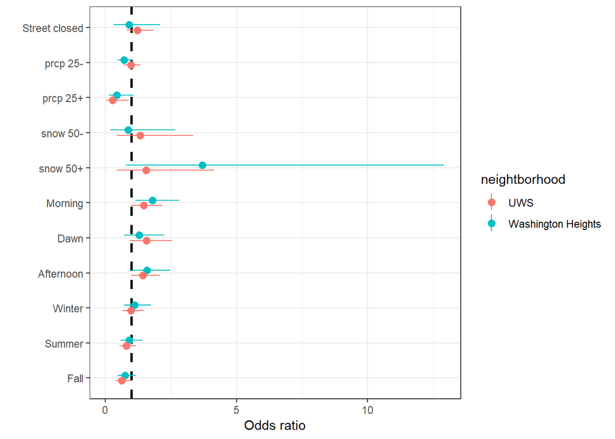

```r
OR_UWS =
 ggplot(table_results_uws, aes(x = term, y = OR)) +
  geom_hline(aes(yintercept = 1), size = 1, linetype = "dashed") +
  geom_pointrange(aes(ymin = conf.low, ymax = conf.high)) +
  coord_flip()

OR_WASH =
  ggplot(table_results_wash, aes(x = term, y = OR)) +
  geom_hline(aes(yintercept = 1), size = 1, linetype = "dashed") +
  geom_pointrange(aes(ymin = conf.low, ymax = conf.high)) +
  coord_flip()

OR_all <-
  table_results_uws %>% bind_rows(table_results_wash) %>%
  ggplot(., aes(x = term, y = OR, colour = neightborhood)) +
  geom_hline(aes(yintercept = 1), size = 1, linetype = "dashed") +
  geom_pointrange(aes(ymin = conf.low, ymax = conf.high),
                  position = position_dodge(width = 0.30)) +
  coord_flip() +
  xlab('') +
  ylab('Odds ratio')

ggsave("OR_all.png", plot = OR_all, width = 45, height = 25, units = "cm")
OR_all
```

#### step 4-4 Fitting regression model by neightborhood

```r
fit_logistic_neighbor =
   glm(over_8min ~ season + hour_of_day + snow_ctg + prcp_ctg + street_closed + neighborhood, family = binomial(), data = dat_subset)

summary(fit_logistic_neighbor)
```

```
##
## Call:
## glm(formula = over_8min ~ season + hour_of_day + snow_ctg + prcp_ctg +
##     street_closed + neighborhood, family = binomial(), data = dat_subset)
##
## Deviance Residuals:
##     Min       1Q   Median       3Q      Max
## -0.6117  -0.3945  -0.3562  -0.3119   2.7517
##
## Coefficients:
##                             Estimate Std. Error z value Pr(>|z|)
## (Intercept)                 -2.81570    0.16282 -17.294  < 2e-16 ***
## seasonFall                  -0.37896    0.16624  -2.280  0.02263 *
## seasonSummer                -0.18311    0.14944  -1.225  0.22048
## seasonWinter                 0.05325    0.15168   0.351  0.72553
## hour_of_dayafternoon         0.40097    0.14289   2.806  0.00501 **
## hour_of_daydawn              0.36221    0.19103   1.896  0.05795 .
## hour_of_daymorning           0.47460    0.14988   3.167  0.00154 **
## snow_ctghigh                 0.77128    0.42623   1.810  0.07036 .
## snow_ctglow                  0.09757    0.39631   0.246  0.80553
## prcp_ctghigh                -0.89831    0.39781  -2.258  0.02394 *
## prcp_ctglow                 -0.15267    0.12436  -1.228  0.21959
## street_closed                0.13713    0.16726   0.820  0.41232
## neighborhoodUpper West Side -0.04894    0.11289  -0.434  0.66464
## ---
## Signif. codes:  0 '***' 0.001 '**' 0.01 '*' 0.05 '.' 0.1 ' ' 1
##
## (Dispersion parameter for binomial family taken to be 1)
##
##     Null deviance: 2884.1  on 6064  degrees of freedom
## Residual deviance: 2853.0  on 6052  degrees of freedom
## AIC: 2879
##
## Number of Fisher Scoring iterations: 6
```

```r
fit_logistic_neighbor %>%
  broom::tidy() %>%
  mutate(OR = exp(estimate)) %>%
  bind_cols(.,  exp(confint_tidy(fit_logistic_neighbor))) %>%
  select(term, OR, conf.low, conf.high) %>%
  filter(term != '(Intercept)') %>%
  mutate(term = c("Fall", "Summer", "Winter", "Afternoon", "Dawn", "Morning", "snow 50+", "snow 50-", "prcp 25+", "prcp 25-", "Street closed", "Washington Heights"))
```

```
## # A tibble: 12 x 4
##    term                  OR conf.low conf.high
##    <chr>              <dbl>    <dbl>     <dbl>
##  1 Fall               0.685    0.493     0.947
##  2 Summer             0.833    0.621     1.12
##  3 Winter             1.05     0.783     1.42
##  4 Afternoon          1.49     1.13      1.98
##  5 Dawn               1.44     0.981     2.08
##  6 Morning            1.61     1.20      2.16
##  7 snow 50+           2.16     0.863     4.70
##  8 snow 50-           1.10     0.471     2.27
##  9 prcp 25+           0.407    0.170     0.825
## 10 prcp 25-           0.858    0.670     1.09
## 11 Street closed      1.15     0.822     1.58
## 12 Washington Heights 0.952    0.763     1.19
```

Washington Height has 1.05 times the odds of response time greater than 8 minutes compared to UWS. However the observed effect is not statistically significant.

### Further Statistical Analysis

- Further research can be planned to investigate the causation of that, but there is something important to keep in mind: the avarage response time is pretty small, and most the of recorded response times are lower than 8 minutes. Thus so far we do not need to worry about the medical emergency service provided in our city.

We also fitted the model with neighborhood as predictor variable and found that Washington Heights had 1.05 times the odds of response time greater than 8 minutes compared to the Upper West Side. However the observed effect is not statistically significant. At least we can be rest assured whether where we live, we still receive equal treatment from the emergency dispatcher.

### Scope for further studies:

- Having established that the emergency response time is relatively satisfactory in New York City, this opens up questions about the qualifications of the emergency responders and what type of care providers at different levels are allowed to provide.
- If all the response vehicles have the necessary equipments to deal with any emergency situation.